# OHIBC: data_prep_spp.Rmd

*Compiled on Wed Sep 30 09:42:18 2015*

## Load species lookup table

Currently this uses the global species lookup table. How this list is generated (file locations are in `~/github/ohiprep/globalprep/SPP_ICO`):

- in `ingest_iucn.R`:
  - Pull full IUCN list from http://api.iucnredlist.org/index/all.csv
  - Filter the list to marine species as indicated on each species page
  - Standardize old extinction risk categories
  - Append population trend and parent/subpop info from species web pages
  - Write to `spp_iucn_mar.csv` in git-annex.
- in `spp_fxn.R::create_spp_master_lookup()`:
  - Pull in Aquamaps species information table, create sciname field and standardize categories
  - Pull in IUCN marine species info from `ingest_iucn.R`
  - `full_join()` the two species lists
  - Determine overall category, trend, and spatial info source (preferring IUCN)
  - Remove duplicate records and data-deficient records
  - Convert text extinction risk category and popn trends to number values
  - Identify parent/subpopulations and aliases within `spatial_source` field.

```
## File /Volumes/data_edit/git-annex/globalprep/SPP_ICO//v2015/intermediate/spp_all.csv:
##   git commit info unavailable.  Not version-tracked in Git?
```

```
##
## Column names in global species lookup table:
```

```
## Observations: 15,676
## Variables: 15
## $ am_sid         (chr) "ITS-552925", "URM-M-1454", "AFD-Pul-494", "ITS...
## $ sciname        (chr) "Thymops birsteini", "Limulus polyphemus", "Aur...
## $ am_category    (chr) NA, NA, "LC", NA, NA, NA, "CR", "LC", "LC", "LC...
## $ iucn_sid       (int) 170038, 11987, 184918, 192532, 189436, 192778, ...
## $ iucn_category  (chr) "LC", "NT", "LC", "VU", "LC", "LC", "CR", "LC",...
## $ popn_trend     (chr) "Unknown", NA, "Unknown", "Unknown", "Stable", ...
## $ parent_sid     (int) NA, NA, NA, NA, NA, NA, NA, NA, NA, NA, NA, NA,...
## $ subpop_sid     (int) NA, NA, NA, NA, NA, NA, NA, NA, NA, NA, NA, NA,...
## $ popn_category  (chr) "LC", "NT", "LC", "VU", "LC", "LC", "CR", "LC",...
## $ info_source    (chr) "iucn", "iucn", "iucn", "iucn", "iucn", "iucn",...
## $ spp_group      (chr) "LOBSTERS", NA, NA, "CONUS", NA, "CONUS", NA, N...
## $ id_no          (int) 170038, NA, NA, 192532, NA, 192778, NA, NA, 170...
## $ spatial_source (chr) "iucn", "am", "am", "iucn", "am", "iucn", "am",...
## $ category_score (dbl) 0.0, 0.2, 0.0, 0.4, 0.0, 0.0, 0.8, 0.0, 0.0, 0....
## $ trend_score    (dbl) NA, NA, NA, NA, 0.0, NA, -0.5, NA, NA, NA, NA, ...
```

```
## Reading OHIBC regions shapefile...
##   ~/github/ohibc/regions/ohibc_rgn_wgs84.shp
```

```
## File ~/github/ohibc/regions/ohibc_rgn_wgs84.shp most recent commit info:
##   commit 43ad53709c74ebbe2f3a2843b6099620f3062a67
##    Author: Casey O'Hara <ohara@nceas.ucsb.edu>
##    Date:   Tue Sep 29 12:18:24 2015 -0700
```

```
## Reading loiczid cell proportions by region from:
##   ~/github/ohibc/spp_ico/v2016/int/cell_id_by_rgn.csv
## File ~/github/ohibc/spp_ico/v2016/int/cell_id_by_rgn.csv most recent commit info:
##   commit 798f35213238967d12d9e54f5d0a121dc3a018ea
##    Author: Casey O'Hara <ohara@nceas.ucsb.edu>
##    Date:   Tue Sep 29 17:35:13 2015 -0700
```

### Map of region ID per cell

*Note that `subs()` can’t deal with duplicate cell IDs; for cells included in two or more regions get the minimum region ID value*

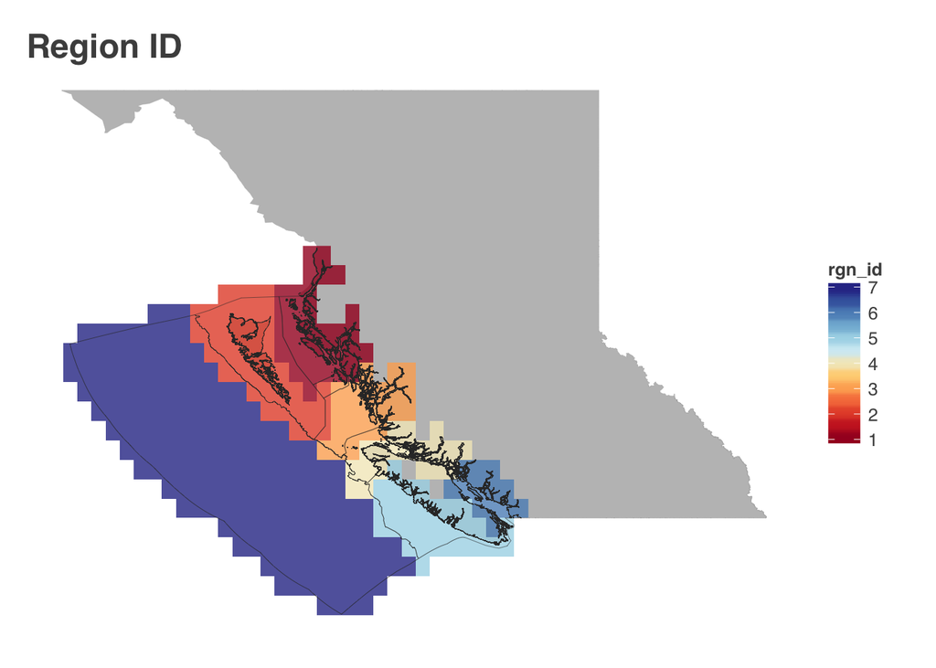